# DMProject FINAL 1.0

[figure not shown]

### Project Member

- Leong Yi Hong (1191100292)
- Alvin Fong Weng Yew (1191100280)
- Tan Sin Zhung (1191100281)

### Install Package

```python
#pip install geopy
#pip install imblearn
#!pip install mlxtend
```

### Import Library

```python
import pandas as pd
import numpy as np
import calendar
import time

import matplotlib.pyplot as plt
import seaborn as sns
import statsmodels.api as sm
import missingno as msno


from numpy import mean
from numpy import std

from scipy import stats
from scipy.stats import f_oneway
from statsmodels.formula.api import ols
from geopy.geocoders import Nominatim

from imblearn.over_sampling import SMOTE

from boruta import BorutaPy
from sklearn.cluster import KMeans
from sklearn.feature_selection import RFECV
from sklearn.preprocessing import MinMaxScaler,LabelEncoder
from sklearn.preprocessing import StandardScaler
from sklearn.model_selection import train_test_split
from sklearn.model_selection import GridSearchCV
from sklearn.model_selection import cross_val_score
from sklearn.model_selection import RepeatedStratifiedKFold

from sklearn.linear_model import LinearRegression
from sklearn.linear_model import LogisticRegression

from sklearn.ensemble import RandomForestClassifier
from sklearn.tree import DecisionTreeClassifier
from sklearn.naive_bayes import GaussianNB
from sklearn.ensemble import StackingClassifier
from sklearn.neighbors import KNeighborsClassifier
from xgboost import XGBClassifier

from sklearn.metrics import accuracy_score, precision_score, recall_score, f1_score
from sklearn.metrics import roc_curve
from sklearn.metrics import roc_auc_score

from mlxtend.frequent_patterns import fpgrowth
from mlxtend.frequent_patterns import association_rules

import warnings
import pickle
warnings.filterwarnings("ignore")
```

## Import Data

```python
df = pd.read_csv("dataset.csv")
df_weather = pd.read_csv("Weather_Cleaned.csv")

pd.options.display.max_columns = len(df.columns)
display(df.head(2))
pd.options.display.max_columns = len(df_weather.columns)
display(df_weather.head(2))
```

|  | Date | Time | Race | Gender | Body_Size | Age_Range | With_Kids | Kids_Category | Basket_Size | Basket_colour | Attire | Shirt_Colour | shirt_type | Pants_Colour | pants_type | Wash_Item | Washer_No | Dryer_No | Spectacles | TimeSpent_minutes | buyDrinks | TotalSpent_RM | latitude | longitude | Num_of_Baskets |
| --- | --- | --- | --- | --- | --- | --- | --- | --- | --- | --- | --- | --- | --- | --- | --- | --- | --- | --- | --- | --- | --- | --- | --- | --- | --- |
| 0 | 19/10/2015 | 20:17:50 | malay | male | moderate | 28.0 | yes | young | big | red | casual | blue | short_sleeve | black | short | clothes | 3 | 10 | no | 20.0 | 2.0 | 9.0 | 2.912316 | 101.657948 | 1.0 |
| 1 | 19/10/2015 | 20:28:42 | NaN | male | thin | 32.0 | no | no_kids | big | NaN | casual | white | short_sleeve | blue_jeans | long | NaN | 6 | 9 | no | 19.0 | 4.0 | 21.0 | 2.922506 | 101.643129 | 3.0 |

|  | name | date | time | temp | feelslike | dew | humidity | precip | precipprob | preciptype | windgust | windspeed | winddir | sealevelpressure | cloudcover | visibility | solarradiation | solarenergy | uvindex | conditions |
| --- | --- | --- | --- | --- | --- | --- | --- | --- | --- | --- | --- | --- | --- | --- | --- | --- | --- | --- | --- | --- |
| 0 | Kuala Lumpur | 01/12/2015 | 00:00:00 | 25.1 | 25.1 | 24.0 | 93.54 | 0.0 | 0 | NaN | NaN | 4.1 | 288.0 | NaN | 89.0 | 10.0 | 0.0 | NaN | 0 | Partially cloudy |
| 1 | Kuala Lumpur | 01/12/2015 | 01:00:00 | 25.0 | 25.0 | 24.0 | 94.19 | 0.0 | 0 | NaN | NaN | 0.6 | 6.0 | NaN | 89.0 | 10.0 | 0.0 | NaN | 0 | Partially cloudy |

```python
df_cleaned = pd.read_csv("Data_Cleaned.csv")
df_cleaned.head()
```

|  | Race | Gender | Body_Size | Age_Range | With_Kids | Kids_Category | Basket_Size | Basket_colour | Attire | Shirt_Colour | ... | windgust | windspeed | winddir | sealevelpressure | cloudcover | visibility | solarradiation | solarenergy | uvindex | conditions |
| --- | --- | --- | --- | --- | --- | --- | --- | --- | --- | --- | --- | --- | --- | --- | --- | --- | --- | --- | --- | --- | --- |
| 0 | malay | male | moderate | 28.0 | yes | young | big | red | casual | blue | ... | 31.7 | 5.3 | 143.0 | 1009.9 | 89.1 | 4.0 | 0.0 | 1.3 | 0.0 | Partially cloudy |
| 1 | NaN | male | thin | 32.0 | no | no_kids | big | NaN | casual | white | ... | 31.7 | 5.3 | 143.0 | 1009.9 | 89.1 | 4.0 | 0.0 | 1.3 | 0.0 | Partially cloudy |
| 2 | malay | female | moderate | 30.0 | no | no_kids | big | blue | casual | red | ... | 31.7 | 5.4 | 107.0 | 1011.4 | 89.1 | 4.0 | 0.0 | 1.3 | 0.0 | Partially cloudy |
| 3 | indian | male | thin | 51.0 | no | no_kids | NaN | black | casual | black | ... | 31.7 | 1.8 | 96.0 | 1011.4 | 89.1 | 3.0 | 0.0 | 1.3 | 0.0 | Partially cloudy |
| 4 | indian | male | NaN | 34.0 | no | no_kids | big | blue | casual | blue | ... | 31.7 | 1.8 | 96.0 | 1011.4 | 89.1 | 3.0 | 0.0 | 1.3 | 0.0 | Partially cloudy |

5 rows × 40 columns

```python
df_cleaned.shape
```

```
(4000, 40)
```

# PART 1. Exploratory Data Analysis

## Data Discretization

- You May Skip This Step (Data Discretization) and proceed with the Data Transformation Section using the (Data_Cleaned.csv)

#### Extract Location From Coordinates

- Extract the area from the address
  - example: Desa Pinggiran Putra, Sepang, Selangor, 62150, Malaysia -> Cyberjaya
- Cleaning the area
  - example: Presint 1 -> Putrajaya
  - example: Setapak -> Kuala Lumpur

```python
geoLoc = Nominatim(user_agent="GetLoc")

def locName(coord):
    address = geoLoc.reverse(coord)
    address = str(address)
    return address

def getArea(address):
    add = address.split(',')

    #data less then 4 item, will be taking the last 3 items.
    if len(add) < 4:
        return add[-3]

    #assuming last 4 is the area
    else:
        return add[-4]
```

*Functions Take 30 Minutes to run* ↓ (depends on the hardwares spec)

```python
#Merging Coordinate for extracting purposes
df['location'] = df['latitude'].astype(str) + ', ' + df['longitude'].astype(str)
df['Location Name'] = df['location'].apply(locName)

df['Area'] = df['Location Name'].apply(getArea)

#Pre-cleaned list to categorized the incorrect classified data
arealist = pd.read_csv('arealist.csv')

#replace the incorrect data
df['Area'] = df['Area'].replace(arealist['Area'].to_list(), arealist['Change'].to_list())
```

#### Extracting time information

- Time of the day (Morning, Afternoon, Evening, Night)
- Round the time for merging
- Get the Days info (Mon, Tue, Wed, ...)

```python
def cleanTime(data):
    data = data.replace(';', ':')
    return data

def getDay(day):
    data = pd.to_datetime(day,format='%d/%m/%Y')
    return calendar.day_name[data.weekday()]

def getTimeOfTheDay(time):
    data = pd.to_datetime(time,format='%H:%M:%S')
    hours = data.hour
    if hours < 12:
        return 'Morning'
    elif hours < 17:
        return 'Afternoon'
    elif hours < 21:
        return 'Evening'
    else:
        return 'Night'

def roundTime(time):
    data = pd.to_datetime(time,format='%H:%M:%S')
    if (data.minute >= 30):
        data = str((data.hour+1))+":00:00"
    else:
        data = str((data.hour))+":00:00"

    if data == "24:00:00":
        data = "00:00:00"

    data = pd.to_datetime(data,format='%H:%M:%S')
    return data.strftime('%H:%M:%S')
```

```python
#Clean Time
df['Time'] = df['Time'].apply(cleanTime)

#Change Date/Time Format
df['Date'] = pd.to_datetime(df.Date,format='%d/%m/%Y').dt.strftime('%d/%m/%Y')
df['Time'] = pd.to_datetime(df.Time,format='%H:%M:%S').dt.strftime('%H:%M:%S')

#Get Mon, Tue, Wed, ...
df['Day'] = df['Date'].apply(getDay)

#Get Morning Afternoon Night....
df['Time_Of_The_Day'] = df['Time'].apply(getTimeOfTheDay)

#Round the time for merging later on
df['Round_Time'] = df['Time'].apply(roundTime)

pd.options.display.max_columns = len(df.columns)
df.head(2)
```

#### Discretize the user into 0 and 1

```python
# Discretize the user to 1 = (with the purchase of drink) and 0 = (without the purchase of drink)
def drink(data):
    if data > 0:
        return 1
    else:
        return 0

df['buyDrink'] = df['buyDrinks'].apply(drink)

pd.options.display.max_columns = len(df.columns)
df
```

## Data Integration

```python
merge_df = pd.merge(df, df_weather, how="left", left_on=['Area','Date','Round_Time'], right_on=['name', 'date','time']);
```

## Data Cleaning

### Check Missing Values

```python
merge_df.isnull().sum()
msno.bar(df)
```

### Drop unwanted column

```python
#Dropping Column
merge_df = merge_df.drop(columns=['buyDrinks','Area','Date','Time','location','latitude','longitude','Location Name','name','date','time','Round_Time'],axis=1)

pd.options.display.max_columns = len(merge_df.columns)
merge_df.head(5)
```

### Fill NA

```python
#Fill NA with median number in numeric columns
col_list = merge_df.select_dtypes(include=['number']).columns.tolist()

for col in col_list:
    merge_df[col] = merge_df[col].fillna(df[col].median())

merge_df.to_csv('DATA_Cleaned.csv',index = False)
```

## Data Transformation

### Label Encoding

```python
df_encode = df_cleaned.copy()
df_encode = df_encode.apply(LabelEncoder().fit_transform)
df_encode.head()
```

|  | Race | Gender | Body_Size | Age_Range | With_Kids | Kids_Category | Basket_Size | Basket_colour | Attire | Shirt_Colour | ... | windgust | windspeed | winddir | sealevelpressure | cloudcover | visibility | solarradiation | solarenergy | uvindex | conditions |
| --- | --- | --- | --- | --- | --- | --- | --- | --- | --- | --- | --- | --- | --- | --- | --- | --- | --- | --- | --- | --- | --- |
| 0 | 3 | 1 | 1 | 10 | 1 | 4 | 0 | 8 | 0 | 2 | ... | 3 | 53 | 145 | 36 | 26 | 28 | 0 | 13 | 0 | 1 |
| 1 | 4 | 1 | 2 | 14 | 0 | 1 | 0 | 11 | 0 | 10 | ... | 3 | 53 | 145 | 36 | 26 | 28 | 0 | 13 | 0 | 1 |
| 2 | 3 | 0 | 1 | 12 | 0 | 1 | 0 | 1 | 0 | 9 | ... | 3 | 54 | 110 | 51 | 26 | 28 | 0 | 13 | 0 | 1 |
| 3 | 2 | 1 | 2 | 33 | 0 | 1 | 2 | 0 | 0 | 0 | ... | 3 | 18 | 99 | 51 | 26 | 20 | 0 | 13 | 0 | 1 |
| 4 | 2 | 1 | 3 | 16 | 0 | 1 | 0 | 1 | 0 | 2 | ... | 3 | 18 | 99 | 51 | 26 | 20 | 0 | 13 | 0 | 1 |

5 rows × 40 columns

### one-hot encoding

```python
df_onehot = df_cleaned.copy()

col_vars = [col for col in df_onehot.columns.tolist() if df_onehot[col].dtype.name == "object"]

for var in col_vars:
    col_list = 'var'+'_'+var
    col_list = pd.get_dummies(df_onehot[var], prefix = var)
    df_temp = df_onehot.join(col_list)
    df_onehot = df_temp

df_vars = df_onehot.columns.values.tolist()
to_keep = [i for i in df_vars if i not in col_vars]
df_onehot = df_onehot[to_keep]
df_onehot.head()
```

|  | Age_Range | Washer_No | Dryer_No | TimeSpent_minutes | TotalSpent_RM | Num_of_Baskets | buyDrink | temp | feelslike | dew | ... | Day_Wednesday | Time_Of_The_Day_Afternoon | Time_Of_The_Day_Evening | Time_Of_The_Day_Morning | Time_Of_The_Day_Night | preciptype_rain | conditions_Overcast | conditions_Partially cloudy | conditions_Rain, Overcast | conditions_Rain, Partially cloudy |
| --- | --- | --- | --- | --- | --- | --- | --- | --- | --- | --- | --- | --- | --- | --- | --- | --- | --- | --- | --- | --- | --- |
| 0 | 28.0 | 3 | 10 | 20.0 | 9.0 | 1.0 | 1 | 28.9 | 34.1 | 24.8 | ... | 0 | 0 | 1 | 0 | 0 | 0 | 0 | 1 | 0 | 0 |
| 1 | 32.0 | 6 | 9 | 19.0 | 21.0 | 3.0 | 1 | 28.9 | 34.1 | 24.8 | ... | 0 | 0 | 1 | 0 | 0 | 0 | 0 | 1 | 0 | 0 |
| 2 | 30.0 | 4 | 10 | 18.0 | 13.0 | 1.0 | 1 | 28.0 | 32.0 | 24.0 | ... | 0 | 0 | 1 | 0 | 0 | 0 | 0 | 1 | 0 | 0 |
| 3 | 51.0 | 5 | 9 | 13.0 | 16.0 | 1.0 | 1 | 28.0 | 32.0 | 24.0 | ... | 0 | 0 | 0 | 0 | 1 | 0 | 0 | 1 | 0 | 0 |
| 4 | 34.0 | 3 | 9 | 15.0 | 13.0 | 3.0 | 1 | 28.0 | 32.0 | 24.0 | ... | 0 | 0 | 0 | 0 | 1 | 0 | 0 | 1 | 0 | 0 |

5 rows × 105 columns

## Data Imbalance Treatment

```
1    3318
0     682
Name: buyDrink, dtype: int64
```

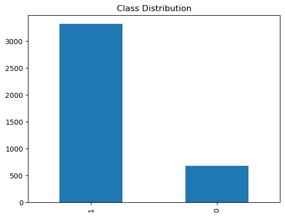

```python
print(df_cleaned["buyDrink"].value_counts())
df_cleaned["buyDrink"].value_counts().plot(kind="bar")
plt.title("Class Distribution")
```

### Over-sampling using SMOTE

```python
smote_X = df_encode.loc[:, df_encode.columns != 'buyDrink']
smote_y = df_encode.loc[:, df_encode.columns == 'buyDrink']

# construct the SMOTE model
os = SMOTE(random_state=42)

# train-test-split with test size 30% and random state=10
X_train, X_test, y_train, y_test = train_test_split(smote_X, smote_y.values.ravel(), test_size = 0.3, random_state=10)
columns = X_train.columns

# fit the smote model with training data only
os_data_X, os_data_y = os.fit_resample(X_train, y_train)

# change to dataframe
os_data_X = pd.DataFrame(data=os_data_X,columns=columns )
os_data_y = pd.DataFrame(data=os_data_y,columns=['buyDrink'])

# we can Check the numbers of our data
print("length of oversampled data is ",len(os_data_X))
print("Number of no subscription in oversampled data",len(os_data_y[os_data_y['buyDrink']==0]))
print("Number of subscription",len(os_data_y[os_data_y['buyDrink']==1]))
print("Proportion of no buy drinks in oversampled data is ",len(os_data_y[os_data_y['buyDrink']==0])/len(os_data_X))
print("Proportion of buy drinks in oversampled data is ",len(os_data_y[os_data_y['buyDrink']==1])/len(os_data_X))
```

```
length of oversampled data is  4700
Number of no subscription in oversampled data 2350
Number of subscription 2350
Proportion of no buy drinks in oversampled data is  0.5
Proportion of buy drinks in oversampled data is  0.5
```

```python
df_smote = pd.concat([os_data_X, os_data_y], axis=1)
df_smote.head()
```

|  | Race | Gender | Body_Size | Age_Range | With_Kids | Kids_Category | Basket_Size | Basket_colour | Attire | Shirt_Colour | ... | windspeed | winddir | sealevelpressure | cloudcover | visibility | solarradiation | solarenergy | uvindex | conditions | buyDrink |
| --- | --- | --- | --- | --- | --- | --- | --- | --- | --- | --- | --- | --- | --- | --- | --- | --- | --- | --- | --- | --- | --- |
| 0 | 3 | 0 | 2 | 39 | 0 | 3 | 0 | 10 | 2 | 8 | ... | 36 | 75 | 44 | 25 | 101 | 214 | 5 | 1 | 3 | 0 |
| 1 | 2 | 1 | 1 | 37 | 1 | 0 | 1 | 2 | 2 | 7 | ... | 76 | 311 | 64 | 25 | 106 | 964 | 28 | 8 | 1 | 0 |
| 2 | 3 | 0 | 1 | 0 | 1 | 4 | 0 | 1 | 1 | 4 | ... | 34 | 218 | 51 | 25 | 88 | 0 | 13 | 0 | 1 | 1 |
| 3 | 2 | 0 | 0 | 29 | 0 | 1 | 0 | 9 | 1 | 12 | ... | 19 | 272 | 42 | 25 | 87 | 0 | 13 | 0 | 3 | 1 |
| 4 | 2 | 0 | 2 | 12 | 0 | 1 | 0 | 1 | 3 | 2 | ... | 54 | 318 | 51 | 25 | 88 | 925 | 27 | 7 | 1 | 1 |

5 rows × 40 columns

```
0    2350
1    2350
Name: buyDrink, dtype: int64
```

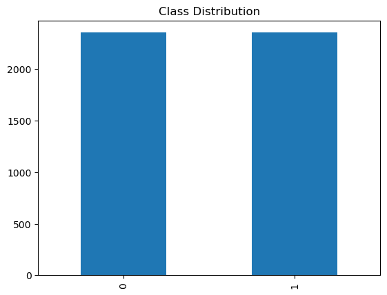

```python
print(df_smote["buyDrink"].value_counts())
df_smote["buyDrink"].value_counts().plot(kind="bar")
plt.title("Class Distribution")
```

### Statistical Test between SMOTE and non-SMOTE dataset

```python
nonSmote = df_encode["buyDrink"]
smote = df_smote["buyDrink"]

print('One Way Anova =>',f_oneway(nonSmote,smote))
```

```
One Way Anova => F_onewayResult(statistic=1172.3037876018905, pvalue=3.855218137919994e-241)
```

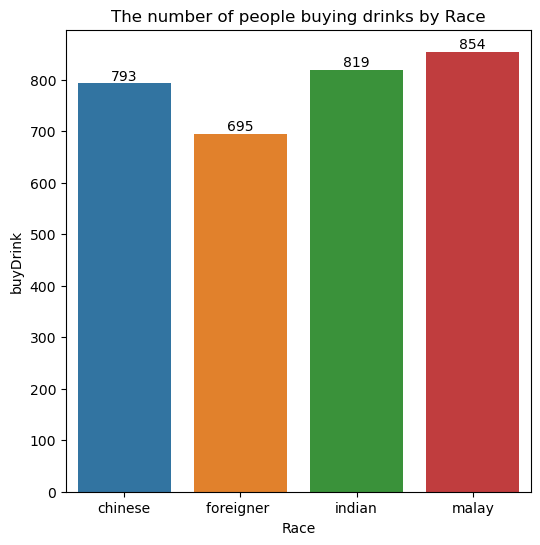

```python
q1 = df_cleaned[['Race','buyDrink']]

q1 = q1.groupby('Race').sum('buyDrink').reset_index()

plt.figure(figsize=(6,6))
ax = sns.barplot(x='Race', y='buyDrink', data=q1)
plt.title('The number of people buying drinks by Race')
for i in ax.containers:
    ax.bar_label(i,)
```

### Question 2: Do basket size and family with kids influence the number of people buying drinks?

|  | sum_sq | df | F | PR(>F) |
| --- | --- | --- | --- | --- |
| C(Basket_Size) | 0.052783 | 1.0 | 0.376358 | 0.539597 |
| C(With_Kids) | 0.006868 | 1.0 | 0.048973 | 0.824872 |
| C(Basket_Size):C(With_Kids) | 0.025529 | 1.0 | 0.182031 | 0.669659 |
| Residual | 507.127142 | 3616.0 | NaN | NaN |

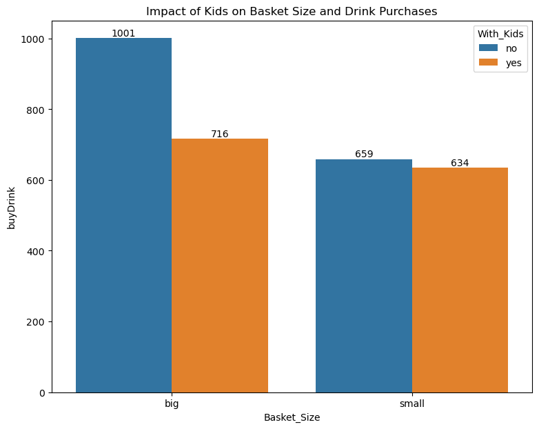

```python
q2 = df_cleaned[['Basket_Size', 'With_Kids', 'buyDrink']]

# Finding mean Monthly Family Expenses for each LifeStyle and Education
q2 = q2.groupby(['Basket_Size','With_Kids']).sum('buyDrink').round(2).reset_index()

#############################################################################
#1 Chart

plt.figure(figsize=(9,7))
ax = sns.barplot(x='Basket_Size', y='buyDrink', hue='With_Kids', data=q2)
plt.title('Impact of Kids on Basket Size and Drink Purchases')

for i in ax.containers:
    ax.bar_label(i,)
#############################################################################

#2 Statistical Test
# Get required data
q2 = df_cleaned[['Basket_Size', 'With_Kids', 'buyDrink']]

# Two Way ANOVA for statistical test
model = ols('buyDrink ~ C(Basket_Size) + C(With_Kids) + C(Basket_Size):C(With_Kids)', data=q2).fit()

sm.stats.anova_lm(model, typ=2)
```

### Question 3: Any correlations between weather information and number of people buying drinks?

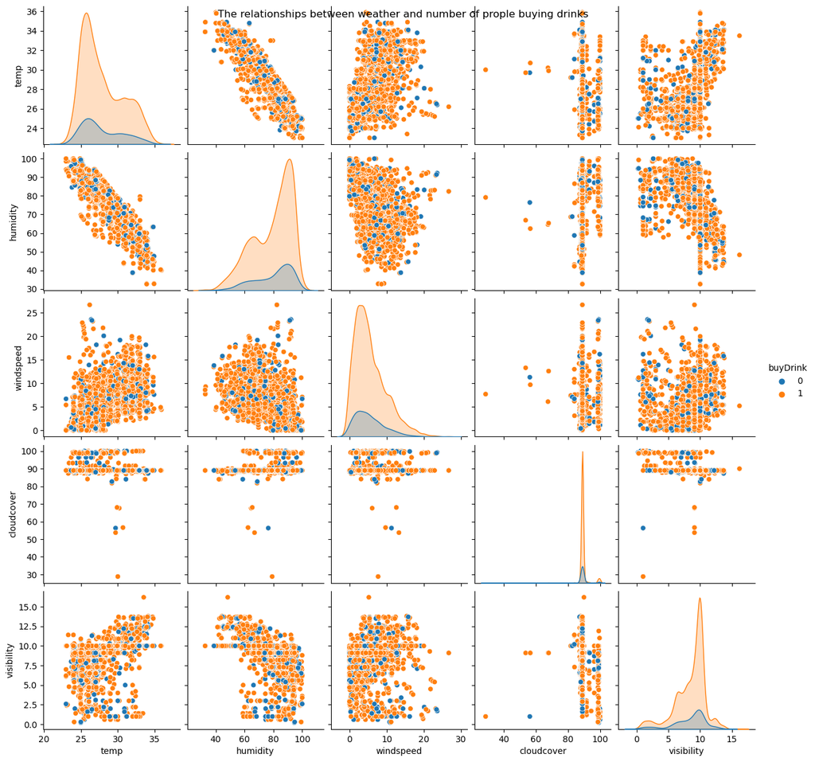

```python
q3 = df_cleaned[['temp', 'humidity', 'windspeed','cloudcover', 'visibility', 'buyDrink']].reset_index(drop=True)

plt.figure(figsize=(8,8))
a = sns.pairplot(q3, hue='buyDrink')
a.fig.suptitle("The relationships between weather and number of prople buying drinks")
```

### Question 4: Are there a difference in average total spent (RM) in laundry shops between each of the age groups?

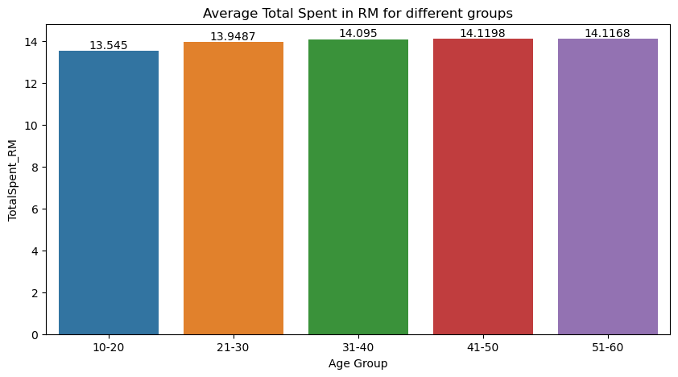

```python
q4 = df_cleaned[['Age_Range','TotalSpent_RM']]

bins = [10, 20, 30, 40, 50, 60]
labels = ['10-20', '21-30', '31-40', '41-50', '51-60']
q4['Age Group'] = pd.cut(q4['Age_Range'], bins=bins, labels=labels)

q4 = q4.groupby('Age Group').mean('TotalSpent_RM').reset_index()

plt.figure(figsize = (10,5))
plt.title('Average Total Spent in RM for different groups')
ax = sns.barplot(x='Age Group', y='TotalSpent_RM', data=q4)
for i in ax.containers:
    ax.bar_label(i,)
```

## K-means Clustering

### Question 5: Does TimeSpent_minutes and Age_Range has differences in terms of buying drinks in laundry shops?

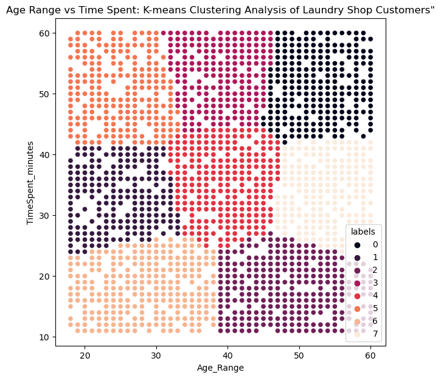

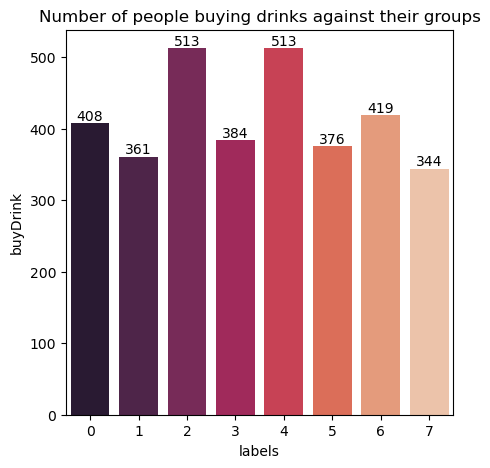

```python
# Load the data
q5 = df_cleaned
q5cl = df_cleaned[['Age_Range','TimeSpent_minutes']]

# Create the KMeans model
kmeans = KMeans(n_clusters=8,random_state=1)

# Fit the model to the data
kmeans.fit(q5cl)

# Get the cluster labels for each data point
q5['labels'] = kmeans.predict(q5cl)


plt.figure(figsize=(7,7))
sns.scatterplot(x="Age_Range", y="TimeSpent_minutes", hue="labels", data=q5,palette='rocket',legend='full')
plt.title('Age Range vs Time Spent: K-means Clustering Analysis of Laundry Shop Customers"')

plt.figure(figsize=(5,5))
q5 = q5.groupby('labels').sum('buyDrink').reset_index()
plt.title('Number of people buying drinks against their groups')

ax = sns.barplot(data=q5, x="labels", y="buyDrink",palette='rocket')
for i in ax.containers:
    ax.bar_label(i,)
```

## Association Rule Mining

### Question 6: What are the most common characteristics of customers that are most likely to come to the laundry shops?

```python
q6 = df_cleaned

pd.options.display.max_columns = len(q6.columns)

q6 = q6[['Race','Gender','Body_Size','With_Kids','Kids_Category','Basket_colour','Attire','Shirt_Colour','shirt_type','Pants_Colour','pants_type','Wash_Item','Day','Time_Of_The_Day','Spectacles']]

# one-hot encoding
oneh = pd.get_dummies(q6)

# Find frequent item sets using the FP-growth algorithm
frequent_item_sets = fpgrowth(oneh, min_support=0.10, use_colnames=True)

# Compute association rules
rules = association_rules(frequent_item_sets, metric='confidence', min_threshold=0.3)

# Display the association rules
rules
```

|  | antecedents | consequents | antecedent support | consequent support | support | confidence | lift | leverage | conviction |
| --- | --- | --- | --- | --- | --- | --- | --- | --- | --- |
| 0 | (pants_type_long) | (Wash_Item_clothes) | 0.54175 | 0.53950 | 0.29575 | 0.545916 | 1.011893 | 0.003476 | 1.014130 |
| 1 | (Wash_Item_clothes) | (pants_type_long) | 0.53950 | 0.54175 | 0.29575 | 0.548193 | 1.011893 | 0.003476 | 1.014260 |
| 2 | (Wash_Item_clothes) | (Spectacles_no) | 0.53950 | 0.53350 | 0.29850 | 0.553290 | 1.037095 | 0.010677 | 1.044302 |
| 3 | (Spectacles_no) | (Wash_Item_clothes) | 0.53350 | 0.53950 | 0.29850 | 0.559513 | 1.037095 | 0.010677 | 1.045433 |
| 4 | (pants_type_long) | (Spectacles_no) | 0.54175 | 0.53350 | 0.29350 | 0.541763 | 1.015488 | 0.004476 | 1.018032 |
| ... | ... | ... | ... | ... | ... | ... | ... | ... | ... |
| 979 | (Race_foreigner ) | (pants_type_long) | 0.20775 | 0.54175 | 0.10450 | 0.503008 | 0.928488 | -0.008049 | 0.922048 |
| 980 | (Race_foreigner ) | (Gender_male) | 0.20775 | 0.47300 | 0.10100 | 0.486161 | 1.027825 | 0.002734 | 1.025614 |
| 981 | (Race_foreigner ) | (Wash_Item_clothes) | 0.20775 | 0.53950 | 0.10650 | 0.512635 | 0.950205 | -0.005581 | 0.944878 |
| 982 | (Race_foreigner ) | (pants_type_short) | 0.20775 | 0.45600 | 0.10300 | 0.495788 | 1.087255 | 0.008266 | 1.078912 |
| 983 | (Race_foreigner ) | (Time_Of_The_Day_Morning) | 0.20775 | 0.49375 | 0.10075 | 0.484958 | 0.982193 | -0.001827 | 0.982929 |

984 rows × 9 columns

# PART 2. Feature Selection

```python
def ranking(ranks, names, order=1):
    minmax = MinMaxScaler()
    ranks = minmax.fit_transform(order*np.array([ranks]).T).T[0]
    ranks = map(lambda x: round(x,2), ranks)
    return dict(zip(names, ranks))
```

## 2.1 Perform Boruta feature Selection

```python
# Feature selection using BORUTA
rf = RandomForestClassifier(n_jobs=-1, class_weight="balanced_subsample", max_depth=5)
boruta = BorutaPy(rf, n_estimators="auto", random_state=1)

y = df_encode["buyDrink"]
X = df_encode.drop("buyDrink", axis = 1)
colnames = X.columns

boruta.fit(X.values, y.values.ravel())
pickle.dump(boruta,open('boruta.fs','wb'))
```

### Display Top-10 and Bottom-10 Features

```python
boruta_score = ranking(list(map(float, boruta.ranking_)), colnames, order=-1)
boruta_score = pd.DataFrame(list(boruta_score.items()), columns=['Features', 'Score'])
boruta_score = boruta_score.sort_values("Score", ascending = False)

print('---------Top 10----------')
display(boruta_score.head(10))

print('---------Bottom 10----------')
display(boruta_score.tail(10))
```

```
---------Top 10----------
```

|  | Features | Score |
| --- | --- | --- |
| 24 | dew | 1.00 |
| 25 | humidity | 0.97 |
| 30 | windspeed | 0.95 |
| 3 | Age_Range | 0.92 |
| 32 | sealevelpressure | 0.87 |
| 34 | visibility | 0.87 |
| 17 | TimeSpent_minutes | 0.87 |
| 31 | winddir | 0.82 |
| 23 | feelslike | 0.79 |
| 22 | temp | 0.76 |

```
---------Bottom 10----------
```

|  | Features | Score |
| --- | --- | --- |
| 10 | shirt_type | 0.24 |
| 26 | precip | 0.21 |
| 38 | conditions | 0.21 |
| 16 | Spectacles | 0.16 |
| 13 | Wash_Item | 0.16 |
| 6 | Basket_Size | 0.11 |
| 12 | pants_type | 0.08 |
| 27 | precipprob | 0.05 |
| 28 | preciptype | 0.03 |
| 29 | windgust | 0.00 |

### Display Top-10 and Bottom-10 Features in barchart

```
<BarContainer object of 10 artists>
```

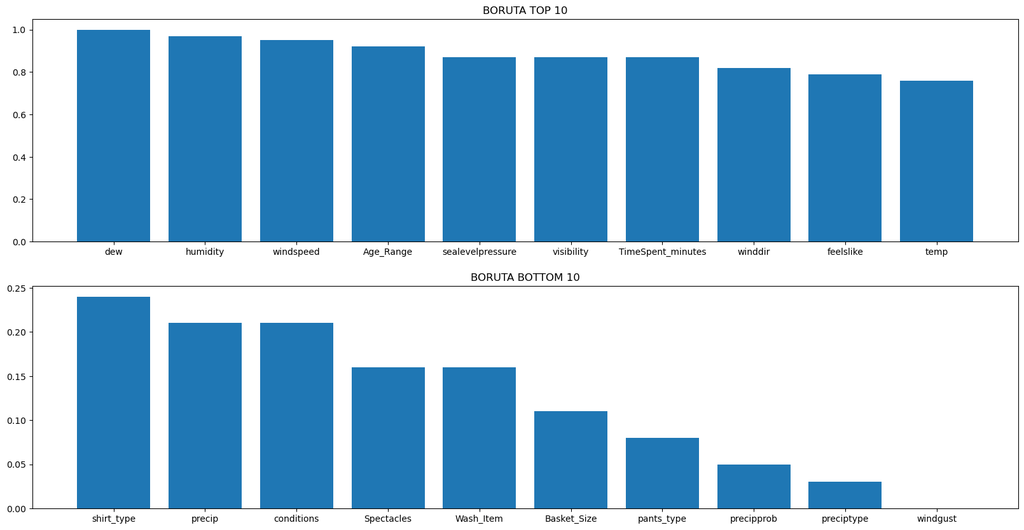

```python
plt.figure(figsize=(20,10))

plt.subplot(2,1,1)
plt.title('BORUTA TOP 10')
plt.bar(boruta_score.head(10)['Features'], boruta_score.head(10)['Score'])

plt.subplot(2,1,2)
plt.title('BORUTA BOTTOM 10')
plt.bar(boruta_score.tail(10)['Features'], boruta_score.tail(10)['Score'])
```

## 2.2 Perform Recursive Feature Elimination (RFE) feature selection

```python
rf = RandomForestClassifier(n_jobs=-1,class_weight='balanced_subsample',max_depth = 5,n_estimators=20,random_state=1)
rf.fit(X,y)
rfe = RFECV(rf,min_features_to_select = 1, cv=2)
rfe.fit(X,y)
pickle.dump(rfe,open('rfe.fs','wb'))
```

### Display Top-10 and Bottom-10 Features

```python
rfe_score = ranking(list(map(float, rfe.ranking_)), colnames, order=-1)
rfe_score = pd.DataFrame(list(rfe_score.items()), columns=['Features', 'Score'])
rfe_score = rfe_score.sort_values("Score", ascending = False)

print('---------Top 10----------')
display(rfe_score.head(10))

print('---------Bottom 10----------')
display(rfe_score.tail(10))
```

```
---------Top 10----------
```

|  | Features | Score |
| --- | --- | --- |
| 15 | Dryer_No | 1.0 |
| 31 | winddir | 1.0 |
| 32 | sealevelpressure | 1.0 |
| 33 | cloudcover | 1.0 |
| 34 | visibility | 1.0 |
| 26 | precip | 1.0 |
| 25 | humidity | 1.0 |
| 24 | dew | 1.0 |
| 23 | feelslike | 1.0 |
| 22 | temp | 1.0 |

```
---------Bottom 10----------
```

|  | Features | Score |
| --- | --- | --- |
| 6 | Basket_Size | 0.69 |
| 21 | Time_Of_The_Day | 0.62 |
| 38 | conditions | 0.54 |
| 10 | shirt_type | 0.46 |
| 1 | Gender | 0.38 |
| 0 | Race | 0.31 |
| 12 | pants_type | 0.23 |
| 29 | windgust | 0.15 |
| 27 | precipprob | 0.08 |
| 28 | preciptype | 0.00 |

### Display Top-10 and Bottom-10 Features in barchart

```
<BarContainer object of 10 artists>
```

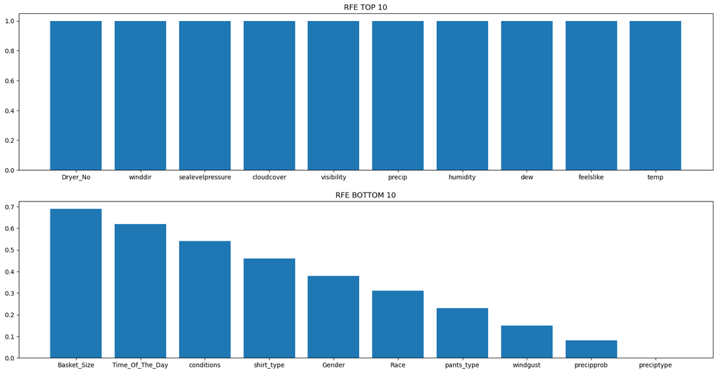

```python
plt.figure(figsize=(20,10))

plt.subplot(2,1,1)
plt.title('RFE TOP 10')
plt.bar(rfe_score.head(10)['Features'], rfe_score.head(10)['Score'])

plt.subplot(2,1,2)
plt.title('RFE BOTTOM 10')
plt.bar(rfe_score.tail(10)['Features'], rfe_score.tail(10)['Score'])
```

## 2.3 Features comparison

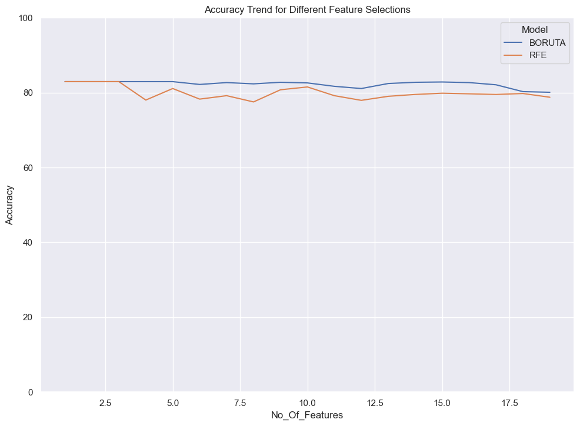

```python
%matplotlib inline
feature_list = ['boruta', 'rfe']
feature_num, acc_rfe, acc_boruta =[],[],[]

for i in range(1, 20):
    feature_num.append(i)
    for feature in feature_list:

        # Create X and y dataset
        y = df_encode['buyDrink']
        X = df_encode.drop('buyDrink', axis = 1)

        clf = GaussianNB()

        if feature == 'boruta':
            cols = boruta_score.Features[0:i]
            X = X[cols].copy()

            # Split data
            X_train, X_test, y_train, y_test = train_test_split(X, y, test_size = 0.3, stratify = y)

            clf.fit(X_train, y_train)
            y_pred = clf.predict(X_test)

            acc = round((accuracy_score(y_test, y_pred)*100), 2)
            acc_boruta.append(acc)

        elif feature == 'rfe':
            cols = rfe_score.Features[0:i]
            X = X[cols].copy()

            # Split data
            X_train, X_test, y_train, y_test = train_test_split(X, y, test_size = 0.3, stratify = y)

            clf.fit(X_train, y_train)
            y_pred = clf.predict(X_test)

            acc = round((accuracy_score(y_test, y_pred)*100), 2)
            acc_rfe.append(acc)

boruta_acc_result = pd.DataFrame(list(zip(feature_num,acc_boruta, acc_rfe)),columns = ["No_Of_Features","BORUTA","RFE"])
boruta_acc_result = pd.melt(boruta_acc_result, id_vars = "No_Of_Features",var_name = "Model", value_name = "Accuracy")

# Plot the line charts
sns.set(rc={'figure.figsize':(11.7,8.27)})

ax = sns.lineplot(x = "No_Of_Features", y = "Accuracy", hue = "Model", data = boruta_acc_result)
ax.set(ylim=(0, 100))
ax.set(title="Accuracy Trend for Different Feature Selections")
plt.show()
```

```python
print(boruta_acc_result[boruta_acc_result["Model"] == "RFE"]['Accuracy'].mean())
print(boruta_acc_result[boruta_acc_result["Model"] == "BORUTA"]['Accuracy'].mean())
```

```
79.89999999999999
82.25947368421053
```

# PART 3 Model Construction and Comparision

## Naive Bayes Classifier

### Create Naive Bayes classifier using Top-5 features

```python
top5_df = df_encode[["dew", "humidity", "windspeed", "Age_Range", "sealevelpressure", "buyDrink"]]

#create X and y dataset
y = top5_df["buyDrink"]
X = top5_df.drop("buyDrink", axis = 1)

#Split train-test dataset
X_train, X_test, y_train, y_test_top5 = train_test_split(X, y, test_size=0.2, stratify = y, random_state = 20)

top5_nb = GaussianNB()

top5_nb.fit(X_train, y_train)
pickle.dump(top5_nb,open('top5.nb','wb'))
y_pred = top5_nb.predict(X_test)

acc_top5nb = top5_nb.score(X_test, y_test_top5)
print("Accuracy: {:.4f}".format(acc_top5nb))

# get the auc score
prob_top5NB = top5_nb.predict_proba(X_test)
prob_top5NB = prob_top5NB[:, 1]

auc_top5NB = roc_auc_score(y_test_top5, prob_top5NB)
print('AUC: %.2f' % auc_top5NB)
```

```
Accuracy: 0.8237
AUC: 0.55
```

### Create Naive Bayes classifier using Top-10 features

```python
top10_df = df_encode[["dew", "humidity", "windspeed", "Age_Range", "sealevelpressure", "visibility", "TimeSpent_minutes",
                       "winddir", "feelslike", "temp", "buyDrink"]]

#create X and y dataset
y = top10_df["buyDrink"]
X = top10_df.drop("buyDrink", axis = 1)

#Split train-test dataset
X_train, X_test, y_train, y_test_top10 = train_test_split(X, y, test_size=0.2, stratify = y, random_state = 20)

top10_nb = GaussianNB()

top10_nb.fit(X_train, y_train)
pickle.dump(top10_nb,open('top10.nb','wb'))
y_pred = top10_nb.predict(X_test)

acc_top10nb = top10_nb.score(X_test, y_test_top10)
print("Accuracy: {:.4f}".format(acc_top10nb))

# get the auc score
prob_top10NB = top10_nb.predict_proba(X_test)
prob_top10NB = prob_top10NB[:, 1]

auc_top10NB = roc_auc_score(y_test_top10, prob_top10NB)
print('AUC: %.2f' % auc_top10NB)
```

```
Accuracy: 0.8225
AUC: 0.53
```

### ROC Curve

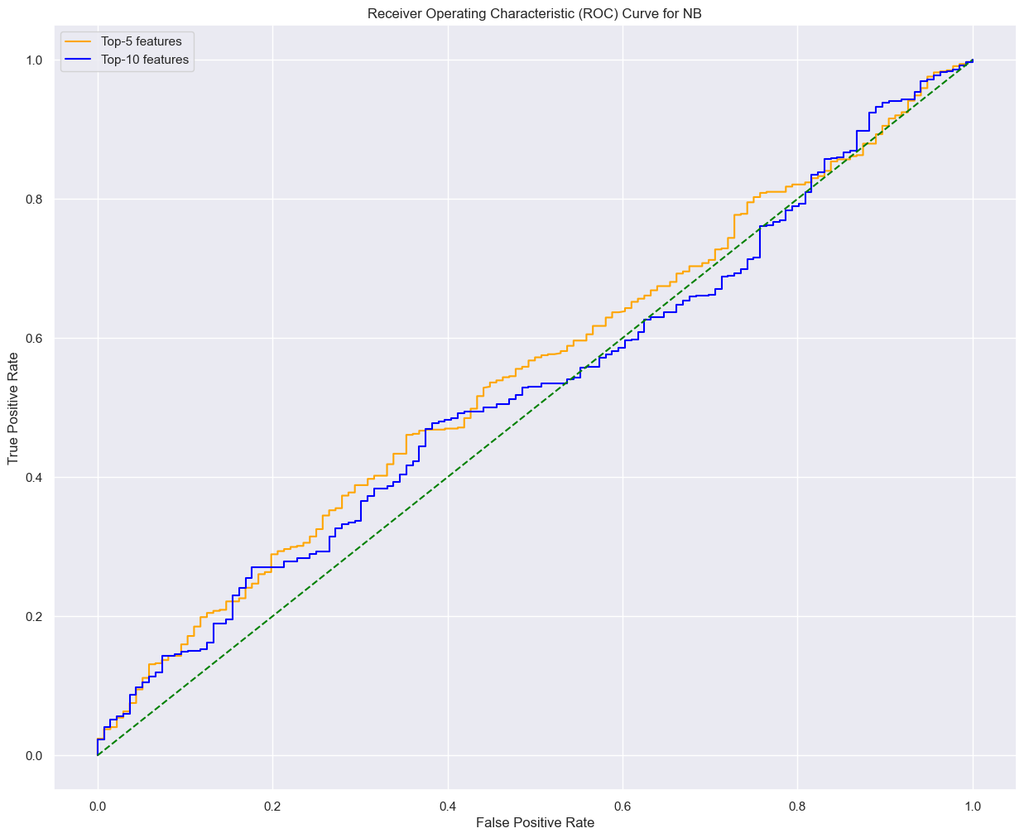

```python
# Plot ROC Curve
fpr_top5NB, tpr_top5NB, thresholds_top5NB = roc_curve(y_test_top5, prob_top5NB)
fpr_top10NB, tpr_top10NB, thresholds_top10NB = roc_curve(y_test_top10, prob_top10NB)

plt.figure(figsize = (15,12))
plt.plot(fpr_top5NB, tpr_top5NB, color='orange', label='Top-5 features')
plt.plot(fpr_top10NB, tpr_top10NB, color='blue', label='Top-10 features')
plt.plot([0, 1], [0, 1], color='green', linestyle='--')
plt.xlabel('False Positive Rate')
plt.ylabel('True Positive Rate')
plt.title('Receiver Operating Characteristic (ROC) Curve for NB')
plt.legend()
```

### Using SMOTE dataset for Naive Bayes classifier (top 5 features)

```python
top5_df_smote = df_smote[["dew", "humidity", "windspeed", "Age_Range", "sealevelpressure", "buyDrink"]]

#create X and y dataset
y = top5_df_smote["buyDrink"]
X = top5_df_smote.drop("buyDrink", axis = 1)

#Split train-test dataset
X_train, X_test, y_train, y_test_top5 = train_test_split(X, y, test_size=0.2, random_state = 50)

top5_nb_smote = GaussianNB()

top5_nb_smote.fit(X_train, y_train)
pickle.dump(top5_nb,open('top5smote.nb','wb'))
y_pred = top5_nb_smote.predict(X_test)

acc_top5nb_smote = top5_nb_smote.score(X_test, y_test_top5)
print("Accuracy: {:.4f}".format(acc_top5nb_smote))

# get the auc score
prob_top5NB = top5_nb.predict_proba(X_test)
prob_top5NB = prob_top5NB[:, 1]

auc_top5NB_smote = roc_auc_score(y_test_top5, prob_top5NB)
print('AUC: %.2f' % auc_top5NB_smote)
```

```
Accuracy: 0.5894
AUC: 0.58
```

### Using SMOTE dataset for Naive Bayes classifier (top 10 features)

```python
top10_df_smote = df_smote[["dew", "humidity", "windspeed", "Age_Range", "sealevelpressure", "visibility", "TimeSpent_minutes",
                       "winddir", "feelslike", "temp", "buyDrink"]]

#create X and y dataset
y = top10_df_smote["buyDrink"]
X = top10_df_smote.drop("buyDrink", axis = 1)

#Split train-test dataset
X_train, X_test, y_train, y_test_top10 = train_test_split(X, y, test_size=0.2, random_state = 50)

top10_nb_smote = GaussianNB()

top10_nb_smote.fit(X_train, y_train)
pickle.dump(top10_nb,open('top10smote.nb','wb'))
y_pred = top10_nb_smote.predict(X_test)

acc_top10nb_smote = top10_nb_smote.score(X_test, y_test_top10)
print("Accuracy: {:.4f}".format(acc_top10nb_smote))

# get the auc score
prob_top10NB = top10_nb.predict_proba(X_test)
prob_top10NB = prob_top10NB[:, 1]

auc_top10NB_smote = roc_auc_score(y_test_top10, prob_top10NB)
print('AUC: %.2f' % auc_top10NB_smote)
```

```
Accuracy: 0.6096
AUC: 0.55
```

### ROC Curve

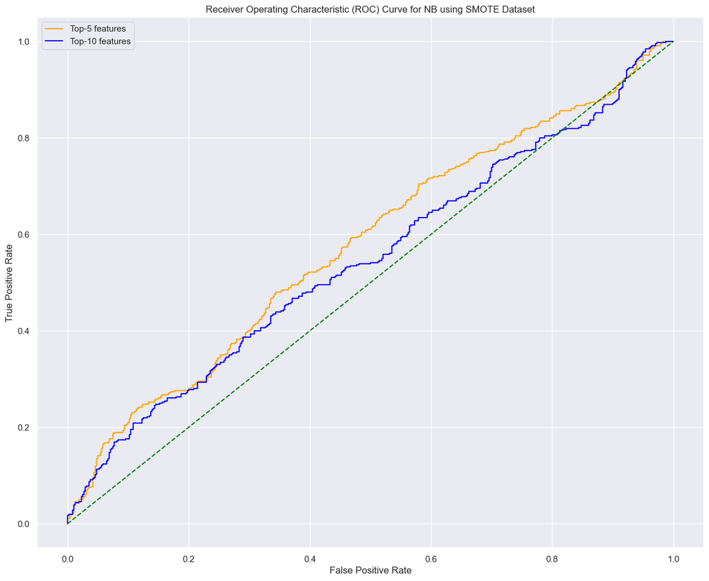

```python
# Plot ROC Curve
fpr_top5NB, tpr_top5NB, thresholds_top5NB = roc_curve(y_test_top5, prob_top5NB)
fpr_top10NB, tpr_top10NB, thresholds_top10NB = roc_curve(y_test_top10, prob_top10NB)

plt.figure(figsize = (15,12))
plt.plot(fpr_top5NB, tpr_top5NB, color='orange', label='Top-5 features')
plt.plot(fpr_top10NB, tpr_top10NB, color='blue', label='Top-10 features')
plt.plot([0, 1], [0, 1], color='green', linestyle='--')
plt.xlabel('False Positive Rate')
plt.ylabel('True Positive Rate')
plt.title('Receiver Operating Characteristic (ROC) Curve for NB using SMOTE Dataset')
plt.legend()
```

## XGboost Classifier

### Create XGBoost classifier using Top-5 features

```python
y = top5_df["buyDrink"]
X = top5_df.drop("buyDrink", axis = 1)

top5_xg = XGBClassifier()

#Split train-test dataset
X_train, X_test, y_train, y_test_top5 = train_test_split(X, y, test_size=0.2, stratify = y, random_state = 20)

top5_xg.fit(X_train, y_train)
pickle.dump(top5_xg,open('top5.xg','wb'))
y_pred = top5_xg.predict(X_test)

acc_top5xg = top5_xg.score(X_test, y_test_top5)
print("Accuracy: {:.4f}".format(acc_top5xg))

# get the auc score
prob_top5XG = top5_xg.predict_proba(X_test)
prob_top5XG = prob_top5XG[:, 1]

auc_top5XG = roc_auc_score(y_test_top5, prob_top5XG)
print('AUC: %.2f' % auc_top5XG)
```

```
Accuracy: 0.8187
AUC: 0.57
```

### Create XGBoost classifier using Top-10 features

```python
#create X and y dataset
y = top10_df["buyDrink"]
X = top10_df.drop("buyDrink", axis = 1)

#Split train-test dataset
X_train, X_test, y_train, y_test_top10 = train_test_split(X, y, test_size=0.2, stratify = y, random_state = 20)

top10_xg = XGBClassifier()

top10_xg.fit(X_train, y_train)
pickle.dump(top10_xg,open('top10.xg','wb'))
y_pred = top10_xg.predict(X_test)

acc_top10xg = top10_xg.score(X_test, y_test_top10)
print("Accuracy: {:.4f}".format(acc_top10xg))

# get the auc score
prob_top10XG = top10_xg.predict_proba(X_test)
prob_top10XG = prob_top10XG[:, 1]

auc_top10XG = roc_auc_score(y_test_top10, prob_top10XG)
print('AUC: %.2f' % auc_top10XG)
```

```
Accuracy: 0.8113
AUC: 0.53
```

### ROC Curve

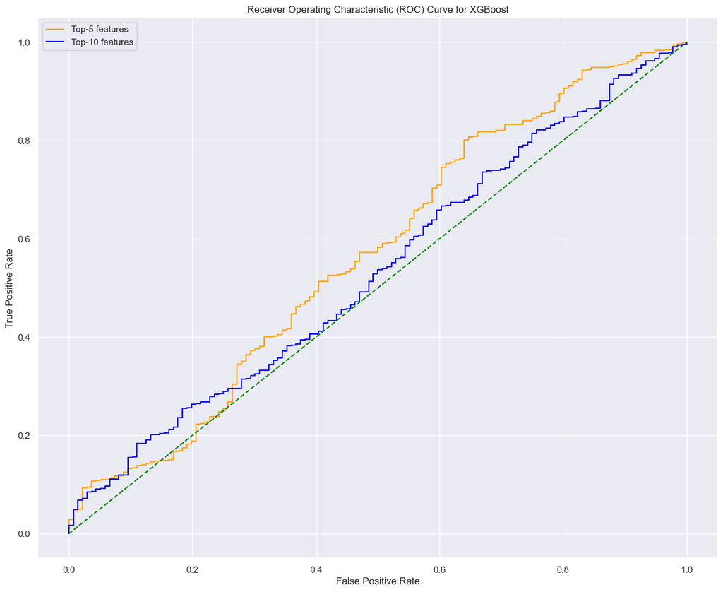

```python
# Plot ROC Curve
fpr_top5XG, tpr_top5XG, thresholds_top5XG = roc_curve(y_test_top5, prob_top5XG)
fpr_top10XG, tpr_top10XG, thresholds_top10XG = roc_curve(y_test_top10, prob_top10XG)

plt.figure(figsize = (15,12))
plt.plot(fpr_top5XG, tpr_top5XG, color='orange', label='Top-5 features')
plt.plot(fpr_top10XG, tpr_top10XG, color='blue', label='Top-10 features')
plt.plot([0, 1], [0, 1], color='green', linestyle='--')
plt.xlabel('False Positive Rate')
plt.ylabel('True Positive Rate')
plt.title('Receiver Operating Characteristic (ROC) Curve for XGBoost')
plt.legend()
```

### Using SMOTE dataset for XGBoost classifier (top5 features)

```python
#create X and y dataset
y = top5_df_smote["buyDrink"]
X = top5_df_smote.drop("buyDrink", axis = 1)

#Split train-test dataset
X_train, X_test, y_train, y_test_top5 = train_test_split(X, y, test_size=0.2, stratify = y, random_state = 40)

top5_xg.fit(X_train, y_train)
pickle.dump(top5_xg,open('top5smote.xg','wb'))
y_pred = top5_xg.predict(X_test)

acc_top5xg_smote = top5_xg.score(X_test, y_test_top5)
print("Accuracy: {:.4f}".format(acc_top5xg_smote))

# get the auc score
prob_top5XG = top5_xg.predict_proba(X_test)
prob_top5XG = prob_top5XG[:, 1]

auc_top5XG_smote = roc_auc_score(y_test_top5, prob_top5XG)
print('AUC: %.2f' % auc_top5XG_smote)
```

```
Accuracy: 0.7553
AUC: 0.83
```

### Using SMOTE dataset for XGBoost classifier (top10 features)

```python
#### create X and y dataset
y = top10_df_smote["buyDrink"]
X = top10_df_smote.drop("buyDrink", axis = 1)

#Split train-test dataset
X_train, X_test, y_train, y_test_top10 = train_test_split(X, y, test_size=0.2, stratify = y, random_state = 40)

top10_xg = XGBClassifier()

top10_xg.fit(X_train, y_train)
pickle.dump(top10_xg,open('top10smote.xg','wb'))
y_pred = top10_xg.predict(X_test)

acc_top10xg_smote = top10_xg.score(X_test, y_test_top10)
print("Accuracy: {:.4f}".format(acc_top10xg_smote))

# get the auc score
prob_top10XG = top10_xg.predict_proba(X_test)
prob_top10XG = prob_top10XG[:, 1]

auc_top10XG_smote = roc_auc_score(y_test_top10, prob_top10XG)
print('AUC: %.2f' % auc_top10XG_smote)
```

```
Accuracy: 0.8298
AUC: 0.90
```

### Plot ROC Curve

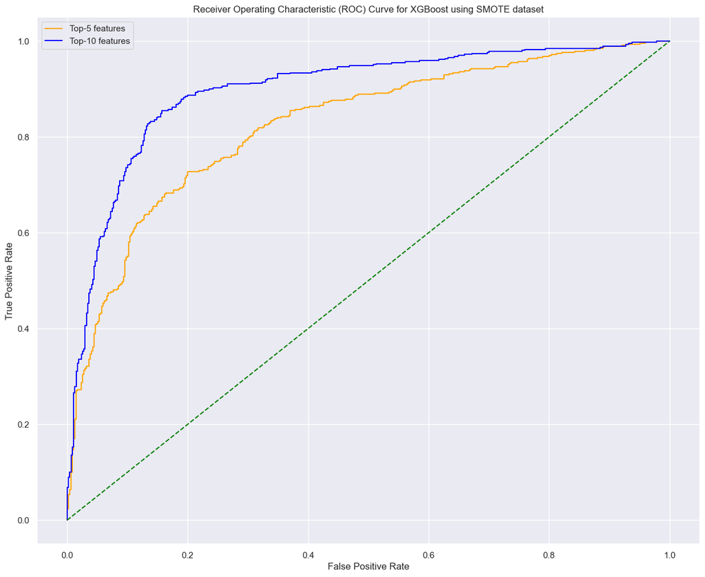

```python
# Plot ROC Curve
fpr_top5XG, tpr_top5XG, thresholds_top5XG = roc_curve(y_test_top5, prob_top5XG)
fpr_top10XG, tpr_top10XG, thresholds_top10XG = roc_curve(y_test_top10, prob_top10XG)

plt.figure(figsize = (15,12))
plt.plot(fpr_top5XG, tpr_top5XG, color='orange', label='Top-5 features')
plt.plot(fpr_top10XG, tpr_top10XG, color='blue', label='Top-10 features')
plt.plot([0, 1], [0, 1], color='green', linestyle='--')
plt.xlabel('False Positive Rate')
plt.ylabel('True Positive Rate')
plt.title('Receiver Operating Characteristic (ROC) Curve for XGBoost using SMOTE dataset')
plt.legend()
```

### non-SMOTE dataset

```python
print("Accuracy of NB using Top 5 features: ", round(acc_top5nb, 4))
print("Accuracy of NB using Top 10 features: ", round(acc_top10nb, 4))
print("Accuracy of XGBoost using Top 5 features: ", round(acc_top5xg, 4))
print("Accuracy of XGBoost using Top 10 features: ", round(acc_top10xg, 4))
```

```
Accuracy of NB using Top 5 features:  0.8238
Accuracy of NB using Top 10 features:  0.8225
Accuracy of XGBoost using Top 5 features:  0.8188
Accuracy of XGBoost using Top 10 features:  0.8112
```

### SMOTE dataset

```python
print("Accuracy of NB using Top 5 features: ", round(acc_top5nb_smote, 4))
print("Accuracy of NB using Top 10 features: ", round(acc_top10nb_smote, 4))
print("Accuracy of XGBoost using Top 5 features: ", round(acc_top5xg_smote, 4))
print("Accuracy of XGBoost using Top 10 features: ", round(acc_top10xg_smote, 4))
```

```
Accuracy of NB using Top 5 features:  0.5894
Accuracy of NB using Top 10 features:  0.6096
Accuracy of XGBoost using Top 5 features:  0.7553
Accuracy of XGBoost using Top 10 features:  0.8298
```

## Hyperparameter Tuning for Naive Bayes classifer

```python
nb = GaussianNB()
print(nb.get_params())
```

```
{'priors': None, 'var_smoothing': 1e-09}
```

```python
#create X and y dataset
y = top5_df["buyDrink"]
X = top5_df.drop("buyDrink", axis = 1)

X_train, X_test, y_train, y_test = train_test_split(X, y, test_size = 0.2, random_state=50)

params_nb = {'var_smoothing': [1e-9, 1e-8, 1e-7, 1e-6, 1e-5]}

grid_nb = GridSearchCV(estimator=nb, param_grid=params_nb, scoring='accuracy', verbose= 2)
grid_nb.fit(X_train, y_train)
pickle.dump(grid_nb,open('nb.hyperparameter','wb'))

# Extract best model from 'grid_nb'
best_model = grid_nb.best_estimator_

# Predict the test set labels
y_pred = best_model.predict(X_test)
```

[output not shown]

```python
# accuracy and AUC
print('\nAccuracy of Tuned Naive Bayes Using Top-5 features: {:.4f}'.format(best_model.score(X_test, y_test)))

# get the auc score
prob_nb = best_model.predict_proba(X_test)
prob_nb = prob_nb[:, 1]

auc_nb = roc_auc_score(y_test, prob_nb)
print('AUC: %.2f' % auc_nb)
```

```
Accuracy of Tuned Naive Bayes Using Top-5 features: 0.8588
AUC: 0.53
```

## Hyperparameter Tuning for XGBoost classifer

```python
xg = XGBClassifier()
print(xg.get_params())
```

```
{'objective': 'binary:logistic', 'use_label_encoder': None, 'base_score': None, 'booster': None, 'callbacks': None, 'colsample_bylevel': None, 'colsample_bynode': None, 'colsample_bytree': None, 'early_stopping_rounds': None, 'enable_categorical': False, 'eval_metric': None, 'feature_types': None, '…
```

```python
#create X and y dataset (top-5 features)
y = top5_df["buyDrink"]
X = top5_df.drop("buyDrink", axis = 1)

X_train, X_test, y_train, y_test = train_test_split(X, y, test_size = 0.2, random_state=50)

params_xg = {'learning_rate': [0.1, 0.01, 0.001],
            'max_depth': [3, 5, 7],}

grid_xg = GridSearchCV(estimator=xg, param_grid=params_xg, scoring='accuracy', verbose= 2)
grid_xg.fit(X_train, y_train)
pickle.dump(grid_xg,open('xg.hyperparameter','wb'))

# Extract best model from 'grid_xg'
best_model = grid_xg.best_estimator_

# Predict the test set labels
y_pred = best_model.predict(X_test)
```

[output not shown]

```python
# Extract best model from 'grid_xg'
best_model = grid_xg.best_estimator_

# Predict the test set labels
y_pred = best_model.predict(X_test)
```

```python
# accuracy and  AUC score
print('Accuracy of Tuned Xgboost classifier Using Top-5 features: {:.4f}'.format(best_model.score(X_test, y_test)))

# get the auc score
prob_xg = best_model.predict_proba(X_test)
prob_xg = prob_xg[:, 1]

auc_xg = roc_auc_score(y_test, prob_xg)
print('AUC: %.2f' % auc_xg)
```

```
Accuracy of Tuned Xgboost classifier Using Top-5 features: 0.8575
AUC: 0.53
```

### ROC Curve

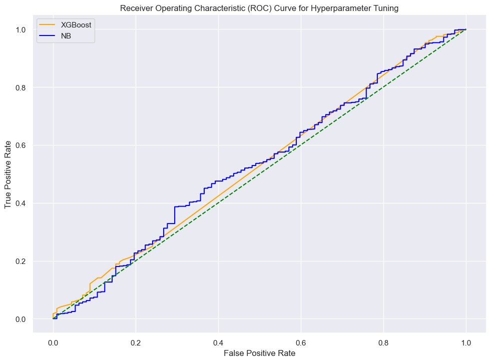

```python
# Plot ROC Curve
fpr_NB, tpr_NB, thresholds_NB = roc_curve(y_test, prob_nb)
fpr_XG, tpr_XG, thresholds_XG = roc_curve(y_test, prob_xg)

plt.plot(fpr_XG, tpr_XG, color='orange', label='XGBoost')
plt.plot(fpr_NB, tpr_NB, color='blue', label='NB')
plt.plot([0, 1], [0, 1], color='green', linestyle='--')
plt.xlabel('False Positive Rate')
plt.ylabel('True Positive Rate')
plt.title('Receiver Operating Characteristic (ROC) Curve for Hyperparameter Tuning')
plt.legend()
```

## Stacking Ensemble Classifier

```
>nb 0.755 (0.138)
>xgboost 0.896 (0.005)
>stacking 0.903 (0.003)
```

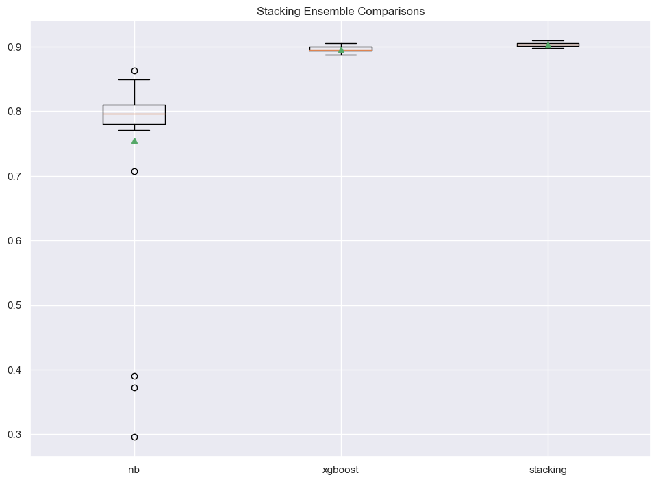

```python
# get a stacking ensemble of models
def get_stacking():
    # define the base models
    level0 = list()
    level0.append(('knn', KNeighborsClassifier()))
    level0.append(('cart', DecisionTreeClassifier()))
    level0.append(('rf', RandomForestClassifier()))

    # define the stacking ensemble
    level1 = RandomForestClassifier()
    model = StackingClassifier(estimators=level0, final_estimator=level1, cv=5)
    return model

# evaluate a given model using cross-validation
def evaluate_model(model, X, y):
    cv = RepeatedStratifiedKFold(n_splits=10, n_repeats=3, random_state=1)
    scores = cross_val_score(model, X, y, scoring='f1', cv=cv, n_jobs=-1, error_score='raise')
    return scores

y = df_onehot.buyDrink
X = df_onehot.drop("buyDrink", 1)
colnames = X.columns

# Train-Test-Split using 20% test data
X_train, X_test, y_train, y_test = train_test_split(X,y,test_size=0.2)

# construct a list of models in a dictionary
models = dict()

models['nb'] = GaussianNB()
models['xgboost'] = XGBClassifier()
models['stacking'] = get_stacking()

results, names = list(), list()

for name,model in models.items():
    scores = evaluate_model(model,X,y)
    results.append(scores)
    names.append(name)
    print('>%s %.3f (%.3f)' % (name,mean(scores),std(scores)))

# Saving the model
with open('stacking_model.pkl', 'wb') as file:
    pickle.dump(models['stacking'], file)

# plot model performance for comparison
plt.boxplot(results, labels=names, showmeans=True)
plt.title('Stacking Ensemble Comparisons')
plt.show()
```

## Linear Regression

```python
df_LinR = df_cleaned.copy()

df_LinR = df_LinR[['Age_Range','TotalSpent_RM']]
df_LinR = df_LinR.groupby('Age_Range').mean().reset_index()

#Put Data in X and y
X = df_LinR[['Age_Range']]     # drop labels from original data
y = df_LinR[["TotalSpent_RM"]]    # copy the labels to another dataframe/series

#Split The Data
X_train, X_test, y_train, y_test = train_test_split(X, y,random_state=1)
#Train The Data
LinR = LinearRegression().fit(X_train, y_train)

#Predict'
predicted = LinR.predict(X_test)

result = pd.DataFrame()
result['Age_Range'] = X_test
result['Actual'] = y_test
result['Predicted'] = predicted
result
```

|  | Age_Range | Actual | Predicted |
| --- | --- | --- | --- |
| 3 | 21.0 | 13.550000 | 13.834253 |
| 2 | 20.0 | 13.430380 | 13.824239 |
| 24 | 42.0 | 13.954955 | 14.044544 |
| 40 | 58.0 | 13.337838 | 14.204766 |
| 17 | 35.0 | 14.103448 | 13.974447 |
| 30 | 48.0 | 13.905263 | 14.104627 |
| 22 | 40.0 | 14.611570 | 14.024516 |
| 36 | 54.0 | 14.476190 | 14.164710 |
| 32 | 50.0 | 14.656566 | 14.124655 |
| 19 | 37.0 | 14.231579 | 13.994474 |
| 21 | 39.0 | 14.212766 | 14.014502 |

```
MAE Score =  0.3480733839058852
R2 Score  =  0.10761214010253839
```

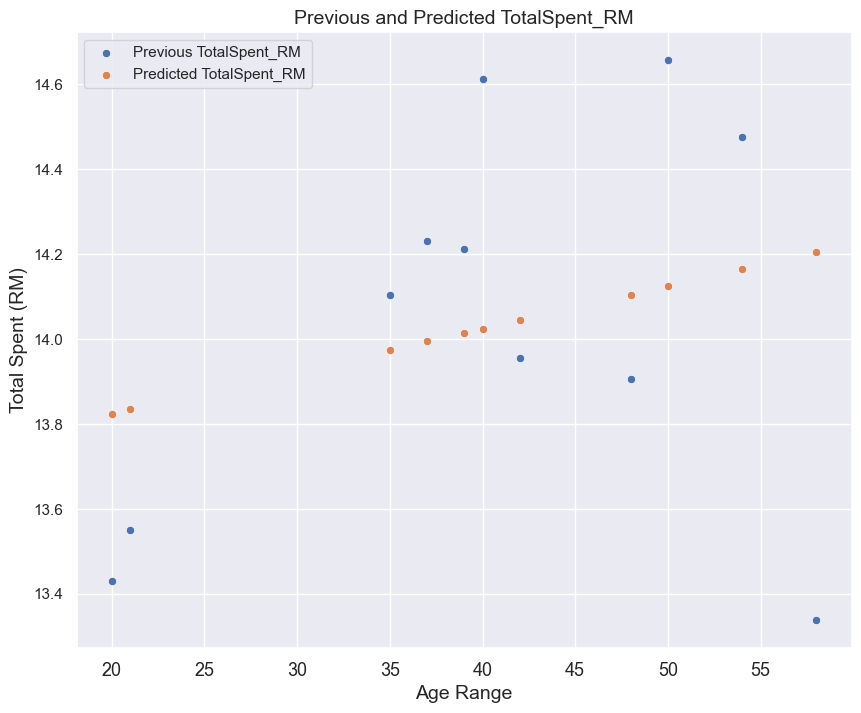

```python
from sklearn.metrics import mean_absolute_error, r2_score

# Calculate MAE
mae = mean_absolute_error(y_test, predicted)

# Calculate R-squared
r2 = r2_score(y_test, predicted)

print("MAE Score = ",mae)
print("R2 Score  = ",r2)

#Plot Line Plot
plt.rc('axes', labelsize= 14)
plt.rc('xtick', labelsize=13)
plt.figure(figsize = (10,8))

x = sns.scatterplot(data=result, y="Actual", x="Age_Range" ,label='Previous TotalSpent_RM')
x = sns.scatterplot(data=result, y="Predicted", x="Age_Range",label='Predicted TotalSpent_RM')
x.set_title('Previous and Predicted TotalSpent_RM',fontsize=14)
plt.xlabel('Age Range')
plt.ylabel('Total Spent (RM)')
```

## Logistic Regression

```python
#create X and y dataset
y = df_encode["buyDrink"]
X = df_encode.drop("buyDrink", axis = 1)

X_train, X_test, y_train, y_test = train_test_split(X, y, test_size = 0.3, random_state=50)

logreg = LogisticRegression(solver='liblinear', max_iter=200)
logreg.fit(X_train, y_train)

y_pred = logreg.predict(X_test)

print('Accuracy of logistic regression: {:.4f}'.format(logreg.score(X_test, y_test)))

# get the auc score
prob_logreg = logreg.predict_proba(X_test)
prob_logreg = prob_logreg[:, 1]

auc_logreg = roc_auc_score(y_test, prob_logreg)
print('AUC: %.2f' % auc_logreg)
```

```
Accuracy of logistic regression: 0.8400
AUC: 0.51
```

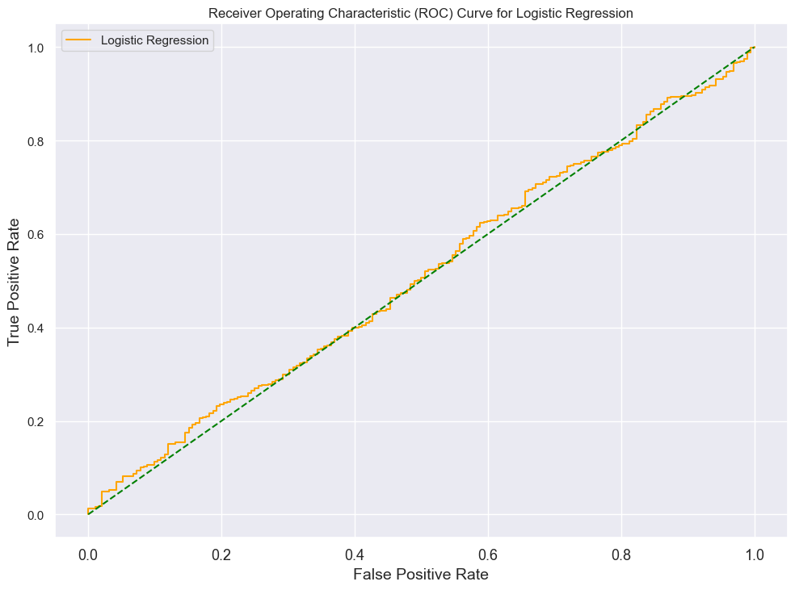

```python
fpr_logreg, tpr_logreg, thresholds_logreg = roc_curve(y_test, prob_logreg)

plt.plot(fpr_logreg, tpr_logreg, color='orange', label='Logistic Regression')
plt.plot([0, 1], [0, 1], color='green', linestyle='--')
plt.xlabel('False Positive Rate')
plt.ylabel('True Positive Rate')
plt.title('Receiver Operating Characteristic (ROC) Curve for Logistic Regression')
plt.legend()
```

### Using SMOTE for Logistic regression

```python
#create X and y dataset
y = df_smote["buyDrink"]
X = df_smote.drop("buyDrink", axis = 1)

X_train, X_test, y_train, y_test = train_test_split(X, y, test_size = 0.2, random_state=50)

logreg = LogisticRegression(solver='liblinear', max_iter=200)
logreg.fit(X_train, y_train)

y_pred = logreg.predict(X_test)

print('Accuracy of logistic regression: {:.4f}'.format(logreg.score(X_test, y_test)))

# get the auc score
prob_logreg = logreg.predict_proba(X_test)
prob_logreg = prob_logreg[:, 1]

auc_logreg = roc_auc_score(y_test, prob_logreg)
print('AUC: %.2f' % auc_logreg)
```

```
Accuracy of logistic regression: 0.7404
AUC: 0.82
```

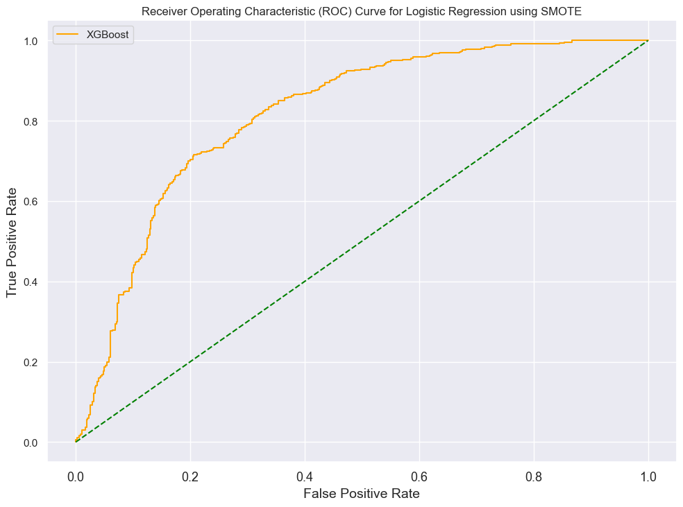

```python
fpr_XG, tpr_XG, thresholds_XG = roc_curve(y_test, prob_logreg)

plt.plot(fpr_XG, tpr_XG, color='orange', label='XGBoost')
plt.plot([0, 1], [0, 1], color='green', linestyle='--')
plt.xlabel('False Positive Rate')
plt.ylabel('True Positive Rate')
plt.title('Receiver Operating Characteristic (ROC) Curve for Logistic Regression using SMOTE')
plt.legend()
```